# What’s up with regression?

Anthony

Oct 15 2023

**Directions**: You are encouraged to work together! Write your solutions in Rmarkdown and submit your solutions as a rendered HTML or PDF file. Only (sufficiently well done) HTML or PDF submissions will be counted as complete. Install packages in your R console and only load them in your markdown file. Installing packages in your markdown file will create an error.

In the first two questions of this homework, we will once again analyze data from the National Longitudinal Survey of Youth 1979 to measure the correlation between income and years of education.

The data file `nlsy79.csv` includes this information and some additional variables we may use later in the course. A description of the variables in the data is in the table below.

| Name | Description |
| --- | --- |
| `CASEID` | Unique identifier |
| `earn2009` | Earnings in 2009 |
| `hgc` | Years of education |
| `race` | Race and Ethnicity |
| `sex` | Gender |
| `bmonth` | Birth Month |
| `byear` | Birth Year |
| `afqt` | Armed Forces Qualifying Test Percentile |
| `region_1979` | Region |
| `faminc1978` | Family Income in 1978 |
| `nsibs79` | Number of Siblings |

# 1. The Shape of the Returns to Schooling

1. Regress earnings on years of education. How much do earnings increase on average for every additional year of schooling?

```r
# Regression: Earnings on Years of Education
reg1 <- lm(earn2009 ~ hgc, data = nlsy79)

# If results look like code, switch type!
# E.g. switch type to "text" if viewing in console
stargazer(reg1,keep.stat=c("n","rsq"),
          covariate.labels=c("Years of Education"),
          dep.var.labels=c("Earnings"), type = 'text')
```

```
##
## ==============================================
##                        Dependent variable:
##                    ---------------------------
##                             Earnings
## ----------------------------------------------
## Years of Education        9,948.762***
##                             (349.656)
##
## Constant                 -82,664.080***
##                            (4,719.534)
##
## ----------------------------------------------
## Observations                  4,334
## R2                            0.157
## ==============================================
## Note:              *p<0.1; **p<0.05; ***p<0.01
```

This coefficient indicates $9,948.764 earnings increase, on average, for every additional year of schooling.

2. Use ggplot2 to plot the conditional expectation of earnings with respect to years of education? Do you think it is reasonable to assume earnings increase linearly with years of schooling?

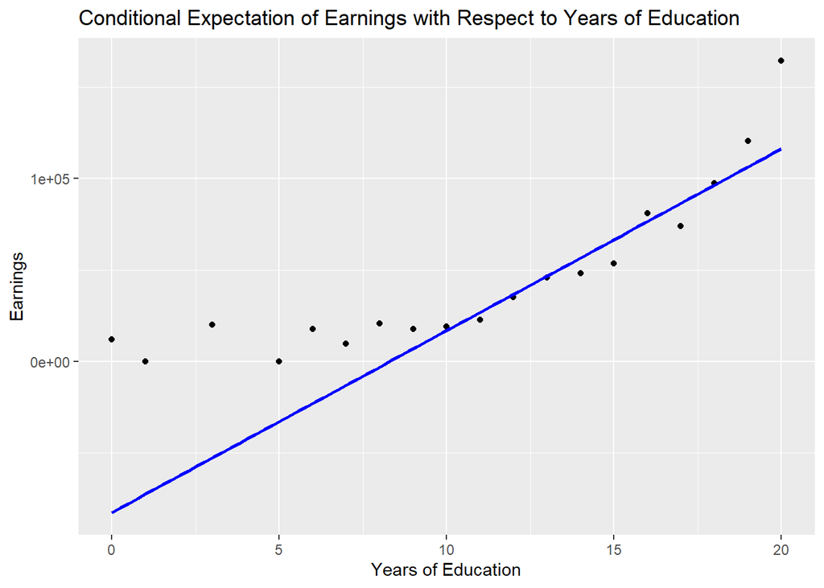

```r
# Plotting the conditional expectation using ggplot2
ggplot(nlsy79, aes(x = hgc, y = earn2009)) +
  geom_point(stat="summary", fun="mean") +
  geom_smooth(method = "lm", se = FALSE, color = "blue") +
  labs(x = "Years of Education", y = "Earnings") +
  ggtitle("Conditional Expectation of Earnings with Respect to Years of Education")
```

We cannot assume earnings increase linearly with years of schooling. As points deviate significantly from the line, it might indicate a non-linear relationship, and other modeling techniques might be more appropriate.The shape of these points seem to be fit for y=e^x.

3. Generate a variable that equals years of education squared. Regress earnings on years of education and years of education squared. How much do earnings increase for someone who gets 10 instead of 9 years of schooling? What about someone who gets 17 instead of 16

```r
# Generate a variable for years of education squared
nlsy79 <- nlsy79 %>%
  mutate(hgc_squared = hgc^2)

# Regression: Earnings on Years of Education and Years of Education Squared
reg2 <- lm(earn2009 ~ hgc + hgc_squared, data = nlsy79)

# If results look like code, switch type!
# E.g. switch type to "text" if viewing in console
stargazer(reg2,keep.stat=c("n","rsq"),
          covariate.labels=c("Years of Education "),
          dep.var.labels=c("Earnings"), type = 'text')
```

```
##
## ==============================================
##                        Dependent variable:
##                    ---------------------------
##                             Earnings
## ----------------------------------------------
## Years of Education        -9,711.773***
##                            (2,375.713)
##
## hgc_squared                719.434***
##                             (86.002)
##
## Constant                  47,122.710***
##                           (16,206.080)
##
## ----------------------------------------------
## Observations                  4,334
## R2                            0.171
## ==============================================
## Note:              *p<0.1; **p<0.05; ***p<0.01
```

```r
# Calculate the predicted earnings for 16 years of schooling
earnings_16_years <- predict(reg2, newdata = data.frame(hgc = 9, hgc_squared = 9^2))

# Calculate the predicted earnings for 17 years of schooling
earnings_17_years <- predict(reg2, newdata = data.frame(hgc = 10, hgc_squared = 10^2))

# Calculate the difference in predicted earnings
difference_in_earnings <- earnings_17_years - earnings_16_years

# Print the difference in predicted earnings
difference_in_earnings
```

```
##        1
## 3957.468
```

For someone who gets 10 instead of 9 years of schooling,earnings increase 3957.468 .  
For someone who gets 17 instead of 16 years of schooling, earnings increase 14029.54.

4. Code years of education as a factor. Now regress earnings on years of education. Comment on the results.

```r
# Code years of education as a factor
nlsy79 <- nlsy79 %>%
  mutate(hgc_factor = factor(hgc))

# Regression: Earnings on Years of Education (coded as a factor)
reg3 <- lm(earn2009 ~ hgc_factor, data = nlsy79)

# If results look like code, switch type!
# E.g. switch type to "text" if viewing in console
stargazer(reg3,keep.stat=c("n","rsq"),
          dep.var.labels=c("Earnings"), type = 'text')
```

```
##
## ========================================
##                  Dependent variable:
##              ---------------------------
##                       Earnings
## ----------------------------------------
## hgc_factor1          -12,149.910
##                     (69,121.710)
##
## hgc_factor3           7,731.760
##                     (69,121.710)
##
## hgc_factor5          -12,149.910
##                     (56,437.640)
##
## hgc_factor6           5,522.683
##                     (44,119.330)
##
## hgc_factor7          -2,379.608
##                     (41,308.120)
##
## hgc_factor8           8,558.512
##                     (40,516.750)
##
## hgc_factor9           5,569.621
##                     (40,285.710)
##
## hgc_factor10          6,891.023
##                     (40,220.440)
##
## hgc_factor11         10,550.780
##                     (40,230.580)
##
## hgc_factor12         22,972.380
##                     (39,928.540)
##
## hgc_factor13         33,724.240
##                     (40,013.710)
##
## hgc_factor14         36,095.210
```

[output cut: 13 more lines]

```
##
## hgc_factor19       108,284.900***
##                     (40,507.580)
##
## hgc_factor20       152,428.400***
##                     (40,578.200)
##
## Constant             12,149.910
##                     (39,907.440)
##
## ----------------------------------------
## Observations            4,334
## R2                      0.179
## ========================================
## Note:        *p<0.1; **p<0.05; ***p<0.01
```

the regression results shows how earnings differ for individuals with different years of education compared to the reference category (represented by the intercept).

5. Do your answers to this question make you more or less worried about the linearity of linear regression?

I become more worry about the linearity of the dataset points. However, we can always use linear regression to estimate nonlinear function by adjust the power of our independent variables.

# 2. Indicators and Interactions

1. Regress the natural logarithm of earnings on an indicator variable for being male. How do the estimates relate to the average log earnings of men and women?

```r
# Log-transform earnings
nlsy79 <- nlsy79 %>% mutate(ln_earnings = ifelse(earn2009>0,log(earn2009),NA))

# Regression: Log Earnings on Gender (coded as an indicator variable)
l1 <- lm(ln_earnings ~ sex, data = nlsy79)

# If results look like code, switch type!
# E.g. switch type to "text" if viewing in console
stargazer(l1,keep.stat=c("n","rsq"),
          dep.var.labels=c("Log Earnings"), type = 'text')
```

```
##
## ========================================
##                  Dependent variable:
##              ---------------------------
##                     Log Earnings
## ----------------------------------------
## sexMALE               0.522***
##                        (0.034)
##
## Constant              10.327***
##                        (0.024)
##
## ----------------------------------------
## Observations            3,559
## R2                      0.061
## ========================================
## Note:        *p<0.1; **p<0.05; ***p<0.01
```

The coefficient for the sexMALE variable is 0.522. This indicates that earnings of males are around 52.2% (68.5%) higher than females on average.

2. Regress log earnings on years of education and an indicator for being male. Next, regress log earnings on years of education and an indicator for being female. Compare the estimated returns to education from both specifications. What do you notice?

```r
# Code years of education as a factor
nlsy79 <- nlsy79 %>%
  mutate(sex_indicator = factor(sex))

# Log-transform earnings
nlsy79 <- nlsy79 %>% mutate(ln_earnings = ifelse(earn2009>0,log(earn2009),NA))

# Regression: Log Earnings on Gender (coded as an indicator variable)
l2 <- lm(ln_earnings ~ hgc+sex_indicator, data = nlsy79)

# If results look like code, switch type!
# E.g. switch type to "text" if viewing in console
stargazer(l2,keep.stat=c("n","rsq"),
          dep.var.labels=c("Earnings"), type = 'text')
```

```
##
## =============================================
##                       Dependent variable:
##                   ---------------------------
##                            Earnings
## ---------------------------------------------
## hgc                        0.144***
##                             (0.007)
##
## sex_indicatorMALE          0.534***
##                             (0.033)
##
## Constant                   8.372***
##                             (0.093)
##
## ---------------------------------------------
## Observations                 3,506
## R2                           0.172
## =============================================
## Note:             *p<0.1; **p<0.05; ***p<0.01
```

# I am sorry I don’t know how to deal with this question.

3. Regress log earnings on years of education separately for the samples of men and women. Compare these estimates to what you found in part a of this question.
4. Generate the interaction between years of education and indicators for being a man and woman. Regress log earnings on years of education, the interaction between years of education and the indicator for being a woman, and the indicator for being a woman. How do these estimates relate to what you found in part c?
5. Now, also generate a variable equal to the interaction between years of education and an indicator for being a man. Regress log earnings on years of education interacted with being a man and a woman (both interactions, but not years of education alone) and an indicator for being a woman. How do these estimates relate to what you found in part c?

# 3. In a 2004 Nature article (one of the leading scientific publications), Tatem, Guerra, Atkinson, and Hay predict that women will have faster times than men in the Olympic 100 meter dash by the year 2156. This one page article is posted on Canvas.

1. How do the authors come to their conclusion?

a. The authors plotted the winning times of men and women over the years, creating a graph. By fitting linear regression lines to the data points, the authors observed a consistent trend: both men’s and women’s sprint times have been steadily decreasing over the years. The authors then extrapolated these trends into the future, predicting that at the 2156 Olympics, the winning women’s 100-meter sprint time would be faster than the men’s.

2. What assumption do they make about the rate at which men’s and women’s times will improve? (Hint: Are they improving faster or slower over time?) Is this reasonable?

b. The authors assume a linear decrease in sprint times for both men and women, and the rate of improvement remains constant over time. This means they believe that men’s and women’s times are decreasing at a consistent pace.

The assumption is reasonable only for the near future, but not for 100 years more. It ignores the limit of human strength, advancements in training methods, technology, or changes in regulations. Extrapolation is not always reasonable when it goes out of sample.

3. Based on their model, about how fast will men and women run the 100 meter dash in the year 2600?

The winning time may go to -12.5s

# 4. Blog post brainstorm

1. What is a topic you are interested in?

I have two ideas about the blog posting: 1. Study Diversity and productivity of business scholars 2. Replicate the paper Christense et al.(2022,TAR),Why is Corporate Virtue in the Eye of the Beholder? The Case of ESG Ratings. Because the authors didn’t show much visilization and I have several related hypotheses to test.

2. Google that topic and “data”. What do you find?

For the first idea, I have to hand collect CVs of Professors from official website for R1 Universities. I have partial data for the second idea.